# Conditions of optimality for unconstrained and constrained optimization

# Unconstrained optimization

We are going to analyze the optimization problem with no constraints
$$\operatorname*{minimize}_{\bm x \in \mathbb{R}^n} \quad f(\bm x).$$

Why are we considering such an unrealistic problem? After all, every engineering problem is subject to some constraints.

Besides the standard teacher’s answer that we should always start with easier problems, there is another answer: it is common for analysis and algorithms for constrained optimization problems to reformulate them as unconstrained ones and then apply tools for unconstrained problems.

## Local vs global optimality

First, let’s define carefully what we mean by *a minimum* in the unconstrained problem.

**Caution**

For those whose mother tongue does not use articles such as **the** and **a/an** in English, it is worth emphasizing that there is a difference between “the minimum” and “a minimum”. In the former we assume that there is just one minimum, in the latter we make no such assumption.

Consider a (scalar) function of a scalar variable for simplicity. Something like the function whose graph is shown in Fig. 1 below.

[figure not shown]

Figure 1: An example of a scalar function of a scalar real argument that exhibits several local minima and maxima

We say, that the function has a local minimum at $x^\star$ if $f(x)\geq f(x^\star)$ in an $\varepsilon$ neighbourhood. All the red dots in the above figure are local minima. Similarly, of course, the function has a local maximum at $x^\star$ if $f(x)\leq f(x^\star)$ in an $\varepsilon$ neighbourhood. Such local maxima are the green dots in the figure. The smallest and the largest of these are global minima and maxima, respectively.

## Conditions of optimality

Here we consider two types of conditions of optimality for unconstrained minimization problems: necessary and sufficient conditions. Necessary conditions must be satisfied at the minimum, but even when they are, the optimality is not guaranteed. On the other hand, the sufficient conditions need not be satisfied at the minimum, but if they are, the optimality is guaranteed. We show the necessary conditions of the first and second order, while the sufficient condition only of the second order.

### Scalar optimization variable

You may want to have a look at the video, but below we continue with the text that covers (and polishes and sometimes even extends a bit) the content of the video.

[video not shown]

We recall here the fundamental assumption made at the beginning of our introduction to optimization – we only consider optimization variables that are real-valued (first, just scalar $x \in \mathbb R$, later vectors $\bm x \in \mathbb R^n$), and objective functions $f()$ that are sufficiently smooth – all the derivatives exist. Then the conditions of optimality can be derived upon inspecting the Taylor series approximation of the cost function around the minimum.

#### Taylor series approximation around the optimum

Denote $x^\star$ as the (local) minimum of the function $f(x)$. The Taylor series expansion of $f(x)$ around $x^\star$ is

$$f(x^\star+\alpha) = f(x^\star)+\left.\frac{\mathrm{d}f(x)}{\mathrm{d} x}\right|_{x=x^\star}\alpha + \frac{1}{2}\left.\frac{\mathrm{d^2}f(x)}{\mathrm{d} x^2}\right|_{x=x^\star}\alpha^2 + {\color{blue}\mathcal{O}(\alpha^3)},$$
where $\mathcal{O}()$ is called *Big O* and has the property that
$$\lim_{\alpha\rightarrow 0}\frac{\mathcal{O}(\alpha^3)}{\alpha^3} \leq M<\infty.$$

Alternatively, we can write the Taylor series expansion as
$$f(x^\star+\alpha) = f(x^\star)+\left.\frac{\mathrm{d}f(x)}{\mathrm{d} x}\right|_{x=x^\star}\alpha + \frac{1}{2}\left.\frac{\mathrm{d^2}f(x)}{\mathrm{d} x^2}\right|_{x=x^\star}\alpha^2 + {\color{red}o(\alpha^2)},$$
using the *little o* with the property that
$$\lim_{\alpha\rightarrow 0}\frac{o(\alpha^2)}{\alpha^2} = 0.$$

Whether $\mathcal{O}()$ or $\mathcal{o}()$ concepts are used, it is just a matter of personal preference. They both express that the higher-order terms in the expansion tend to be negligible compare to the first- and second-order term as $\alpha$ is getting smaller. $\mathcal O(\alpha^3)$ goes to zero at least as fast as a cubic function, while $o(\alpha^2)$ goes to zero faster than a quadratic function.

It is indeed important to understand that this negligibility of the higher-order terms is only valid asymptotically – for a particular $\alpha$ it may easily happend that, say, the third-order term is still dominating.

#### First-order necessary conditions of optimality

For $\alpha$ sufficiently small, the first-order Taylor series expansion is a good approximation of the function $f(x)$ around the minimum. Since $\alpha$ enters this expansion linearly, the cost function can increase or decrease with $\alpha$, depending on the sign of the first derivative. The only way to ensure that the function as a (local) minimu at $x^\star$ is to have the first derivative equal to zero, that is
$$\boxed{
\left.\frac{\mathrm{d}f(x)}{\mathrm{d} x}\right|_{x=x^\star} = 0.}$$

#### Second-order necessary conditions of optimality

Once the first-order necessary condition of optimality is satisfied, the dominating term (as $\alpha$ is getting smalle) is the second-order term $\frac{1}{2}\left.\frac{\mathrm{d^2}f(x)}{\mathrm{d} x^2}\right|_{x=x^\star}\alpha^2$. Since $\alpha$ is squared, it is the sign of the second derivative that determines the contribution of the whole second-order term to the cost function value. For the minimum, the second derivative must be nonnegative, that is

$$\boxed{\left.\frac{\mathrm{d^2}f(x)}{\mathrm{d} x^2}\right|_{x=x^\star} \geq 0.}$$

For completeness we state that the sign must be nonpositive for the maximum.

#### Second-order sufficient condition of optimality

Following the same line of reasoning as above, the if the second derivative is positive, the miniumum is guaranteed, that is, the sufficient condition of optimality is
$$\boxed{\left.\frac{\mathrm{d^2}f(x)}{\mathrm{d} x^2}\right|_{x=x^\star} > 0.}$$

If the second derivative fails to be positive and is just zero (thus still satisfying the necessary condition), does it mean that the point is not a minimum? No. We must examine higher order terms.

### Vector optimization variable

Once again, should you prefer watching a video, here it is, but below we continue with the text that covers the content of the video.

[video not shown]

#### First-order necessary conditions of optimality

One way to handle the vector variables is to convert the vector problem into a scalar one by fixing a direction to an arbitrary vector $\bm d$ and then considering the scalar function of the form $f(\bm x^\star + \alpha \bm d)$. For convenience we define a new function
$$g(\alpha) \coloneqq f(\bm x^\star + \alpha \bm d)$$
and from now on we can invoke the results for scalar functions. Namely, we expand the $g()$ function around zero as
$$g(\alpha) = g(0) + \frac{\mathrm{d}g(\alpha)}{\mathrm{d}\alpha}\bigg|_{\alpha=0}\alpha + \frac{1}{2}\frac{\mathrm{d}^2 g(\alpha)}{\mathrm{d}\alpha^2}\bigg|_{\alpha=0}\alpha^2 + \mathcal{O}(\alpha^3),$$
and argue that the first-order necessary condition of optimality is
$$\frac{\mathrm{d}g(\alpha)}{\mathrm{d}\alpha}\bigg|_{\alpha=0} = 0.$$

Now, invoking the chain rule, we go back from $g()$ to $f()$
$$\frac{\mathrm{d}g(\alpha)}{\mathrm{d}\alpha}\bigg|_{\alpha=0} = \frac{\partial f(\bm x)}{\partial\bm x}\bigg|_{\bm x=\bm x^\star} \frac{\partial(\bm x^\star + \alpha \bm d)}{\partial\alpha}\bigg|_{\alpha=0} = \frac{\partial f(\bm x)}{\partial\bm x}\bigg|_{\bm x=\bm x^\star}\,\bm d = 0,$$
where $\frac{\partial f(\bm x)}{\partial\bm x}\bigg|_{\bm x=\bm x^\star}$ is a row vector of partial derivatives of $f()$ evaluated at $\bm x^\star$. Since the vector $\bm d$ is arbitrary, the necessary condition is that

$$\frac{\partial f(\bm x)}{\partial\bm x}\bigg|_{\bm x=\bm x^\star} = \mathbf 0,$$

More often than not we use the column vector to store partial derivatives. We call it the gradient of the function $f()$ and denoted it as
$$\nabla f(\bm x) \coloneqq \begin{bmatrix}\frac{\partial f(\bm x)}{\partial x_1} \\ \frac{\partial f(\bm x)}{\partial x_n} \\ \vdots \\ \frac{\partial f(\bm x)}{\partial x_n}\end{bmatrix}.$$

The first-order necessary condition of optimality using gradients is then
$$\boxed{\left.\nabla f(\bm x)\right|_{x=x^\star} = \mathbf 0. }$$

**ImportantGradient is a column vector**

In some literature the gradient $\nabla f(\bm x)$ is defined as a row vector. For the condition of optimality it does not matteer since all we require is that all partial derivatives vanish. But for other purposes in our text we regard the gradient as a vector living in the same vector space $\mathbb R^n$ as the optimization variable. The row vector is sometimes denoted as $\mathrm Df(\bm x)$.

##### Computing the gradient of a scalar function of a vector variable

A convenient way is to compute the differential fist and then to identify the derivative in it. Recall that the differential is the first-order approximation to the increment of the function due to a change in the variable

$$\Delta f \approx \mathrm{d}f = \nabla f(x)^\top \mathrm d \bm x.$$

Finding the differential of a function is conceptually easier than finding the derivative since it is a scalar quantity. When searching for the differential of a composed function, we follow the same rules as for the derivative (such as that the one for finding the differential of a product). Let’s illustrate it using an example.

**Example 1** For the function
$$f(\mathbf x) = \frac{1}{2}\bm{x}^\top\mathbf{Q}\bm{x} + \mathbf{r}^\top\bm{x},$$
where $\mathbf Q$ is symetric, the differential is
$$\mathrm{d}f = \frac{1}{2}\mathrm d\bm{x}^\top\mathbf{Q}\bm{x} + \frac{1}{2}\bm{x}^\top\mathbf{Q}\mathrm d\bm{x} + \mathbf{r}^\top\mathrm{d}\bm{x},$$
in which the first two terms can be combined thanks to the fact that they are scalars
$$\mathrm{d}f = \left(\bm{x}^\top\frac{\mathbf{Q} + \mathbf{Q}^\top}{2} + \mathbf{r}^\top\right)\mathrm{d}\bm{x},$$
and finally, since we assumed that $\mathbf Q$ is a symmetric matrix, we get
$$\mathrm{d}f = \left(\mathbf{Q}\bm{x} + \mathbf{r}\right)^\top\mathrm{d}\bm{x},$$
from which we can identify the gradient as
$$\nabla f(\mathbf{x}) = \mathbf{Q}\mathbf{x} + \mathbf{r}.$$

The first-order condition of optimality is then
$$\boxed{\mathbf{Q}\mathbf{x} = -\mathbf{r}.}$$

Although this was just an example, it is actually a very useful one. Keep this result in mind – necessary condition of optimality of a quadratic function comes in the form of a set of linear equations.

#### Second-order necessary conditions of optimality

As before, we fix the direction $\bm d$ and consider the function $g(\alpha) = f(\bm x^\star + \alpha \bm d)$. We expand the expression for the first derivative as
$$\frac{\mathrm d g(\alpha)}{\mathrm d \alpha} = \sum_{i=1}^{n}\frac{\partial f(\bm x)}{\partial x_i}\bigg|_{\bm x = \bm x^\star} d_i,$$
and differentiating this once again, we get the second derivative
$$\frac{\mathrm d^2 g(\alpha)}{\mathrm d \alpha^2} = \sum_{i,j=1}^{n}\frac{\partial^2 f(\bm x)}{\partial x_ix_j}\bigg|_{\bm x = \bm x^\star}d_id_j$$

$$\begin{aligned}
\frac{\mathrm d^2 g(\alpha)}{\mathrm d \alpha^2}\bigg|_{\alpha=0} &= \sum_{i,j=1}^{n}\frac{\text{d}^2}{\text{d}x_ix_j}f(\bm x)\bigg|_{\bm x = \bm x^\star}d_id_j\\
&= \mathbf d^\text{T} \underbrace{\nabla^\text{2}f(\mathbf x)\bigg|_{\bm x = \bm x^\star}}_\text{Hessian} \mathbf d.
\end{aligned}$$
where $\nabla^2 f(\mathbf x)$ is the Hessian (the symmetrix matrix of the second-order mixed partial derivatives)
$$\nabla^2 f(x) = \begin{bmatrix}
\frac{\partial^2 f(\mathbf x)}{\partial x_1^2} && \frac{\partial^2 f(\mathbf x)}{\partial x_1\partial x_2} && \ldots && \frac{\partial^2 f(\mathbf x)}{\partial x_1\partial x_n}\\
\frac{\partial^2 f(\mathbf x)}{\partial x_2\partial x_1} && \frac{\partial^2 f(\mathbf x)}{\partial x_2^2} && \ldots && \frac{\partial^2 f(\mathbf x)}{\partial x_2\partial x_n}\\
\vdots\\
\frac{\partial^2 f(\mathbf x)}{\partial x_n\partial x_1} && \frac{\partial^2 f(\mathbf x)}{\partial x_n\partial x_2} && \ldots && \frac{\partial^2 f(\mathbf x)}{\partial x_n\partial x_n}.
\end{bmatrix}$$

Since $\bm d$ is arbitrary, the second-order necessary condition of optimality is then
$$\boxed{\nabla^\text{2}f(\mathbf x)\bigg|_{\bm x = \bm x^\star} \succeq 0,}$$
where, once again, the inequality $\succeq$ reads that the matrix is *positive semidefinite*.

#### Second-order sufficient condition of optimality

$$\boxed{\nabla^2 f(\mathbf x)\bigg|_{\bm x = \bm x^\star} \succ 0,}$$
where, once again, the inequality $\succ$ reads that the matrix is *positive definite*.

**Example 2** For the quadratic function $f(\mathbf x) = \frac{1}{2}\mathbf{x}^\mathrm{T}\mathbf{Q}\mathbf{x} + \mathbf{r}^\mathrm{T}\mathbf{x}$, the Hessian is
$$\nabla^2 f(\mathbf{x}) = \mathbf{Q}$$
and the second-order necessary condition of optimality is
$$\boxed{\mathbf{Q} \succeq 0.}$$

Second-order sufficient condition of optimality is then
$$\boxed{\mathbf{Q} \succ 0.}$$

Once again, this was more than just an example – quadratic functions are so important for us that it is worth remembering this result.

## Classification of stationary points

For a stationary (also critical) point $\bm x^\star$, that is, one that satisfies the first-order necessary condition
$$\nabla f(\bm x^\star) = 0,$$

we can classify it as

- Minimum: if $\nabla^2 f(\bm x^\star)\succ 0$,
- Maximum: if $\nabla^2 f(\bm x^\star)\prec 0$,
- Saddle point: if $\nabla^2 f(\bm x^\star)$ is indefinite,
- Singular point: if $\nabla^2 f(\bm x^\star)$ is singular and $\nabla^2 f(\bm x^\star)\succeq 0$ (or $\nabla^2 f(\bm x^\star)\prec 0$).

[video not shown]

**Example 3 (Minimum of a quadratic function)** We consider a quadratic function
$$f(\mathbf x) = \frac{1}{2}\mathbf{x}^\mathrm{T}\mathbf{Q}\mathbf{x} + \mathbf{r}^\mathrm{T}\mathbf{x}$$
for a particular $\mathbf{Q}$ and $\mathbf{r}$.

```julia
Q = [1 1; 1 2]
r = [0, 1]

using LinearAlgebra
x_stationary = -Q\r
eigvals(Q)
```

```
2-element Vector{Float64}:
 0.38196601125010515
 2.618033988749895
```

The matrix is positive definite, so the stationary point is a minimum. In fact, *the* minimum. Surface and contour plots of the function are shown below.

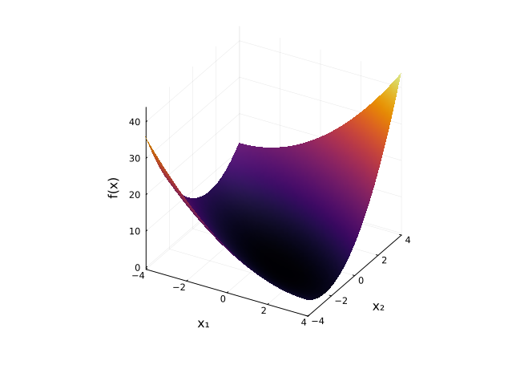

(a) Surface plot

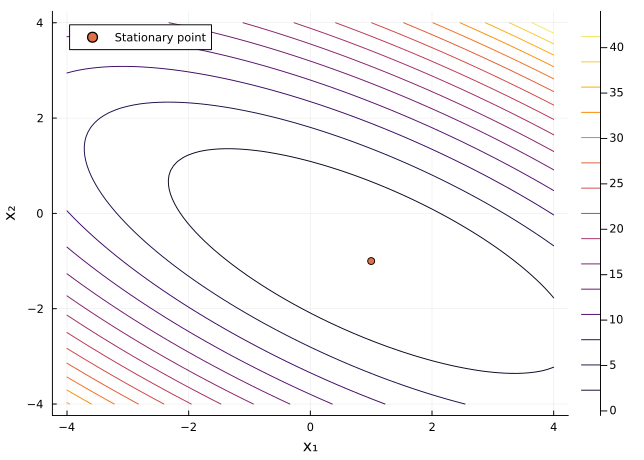

(b) Contour plot

Figure 2: Quadratic function with a minimum

```julia
f(x) = 1/2*dot(x,Q*x)+dot(x,r)
x1_data = x2_data = -4:0.1:4;
f_data = [f([x1,x2]) for x2=x2_data, x1=x1_data];

using Plots

# Create a 2x1 layout for the plots
p1 = surface(x1_data, x2_data, f_data, xlabel="x₁", ylabel="x₂", zlabel="f(x)", colorbar=false)
display(p1)

# Create the second plot (contour)
p2 = contour(x1_data, x2_data, f_data, xlabel="x₁", ylabel="x₂")
# Add the stationary point to the contour plot
scatter!([x_stationary[1]], [x_stationary[2]], marker=:circle, label="Stationary point")
display(p2)
```

**Example 4 (Saddle point of a quadratic function)**

```julia
Q = [-1 1; 1 2]
r = [0, 1]

using LinearAlgebra
x_stationary = -Q\r
eigvals(Q)
```

```
2-element Vector{Float64}:
 -1.3027756377319946
  2.302775637731995
```

The matrix is indefinite, so the stationary point is a saddle point. Surface and contour plots of the function are shown below.

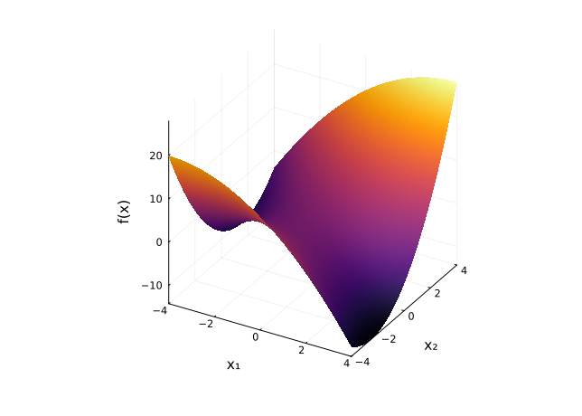

(a) Surface plot

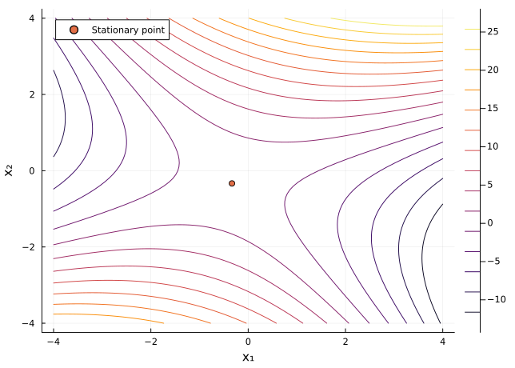

(b) Contour plot

Figure 3: Quadratic function with a saddle point

```julia
f(x) = 1/2*dot(x,Q*x)+dot(x,r)

x1_data = x2_data = -4:0.1:4;
f_data = [f([x1,x2]) for x2=x2_data, x1=x1_data];

using Plots
# Create a 2x1 layout for the plots
p1 = surface(x1_data, x2_data, f_data, xlabel="x₁", ylabel="x₂", zlabel="f(x)", colorbar=false)
display(p1)

# Create the second plot (contour)
p2 = contour(x1_data, x2_data, f_data, xlabel="x₁", ylabel="x₂")
# Add the stationary point to the contour plot
scatter!([x_stationary[1]], [x_stationary[2]], marker=:circle, label="Stationary point")
display(p2)
```

**Example 5 (Singular point of a quadratic function)**

```julia
Q = [2 0; 0 0]
r = [3, 0]

using LinearAlgebra
eigvals(Q)
```

```
2-element Vector{Float64}:
 0.0
 2.0
```

The matrix `Q` is singular, which has two consequences:

- We cannot compute the stationary point since `Q` is not invertible. In fact, there is a whole line (a subspace) of stationary points.
- The matrix `Q` is positive semidefinite, which generally means that optimality cannot be concluded. But in this particular case of a quadratic function, there are no higher-order terms in the Taylor series expansion, so the function attains the minimum at all stationary points.

Surface and contour plots of the function are shown below.

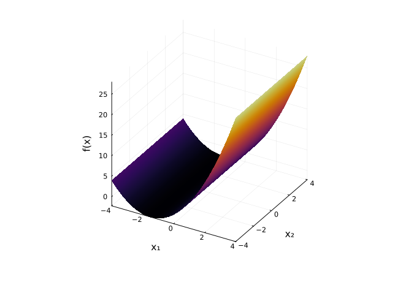

(a) Surface plot

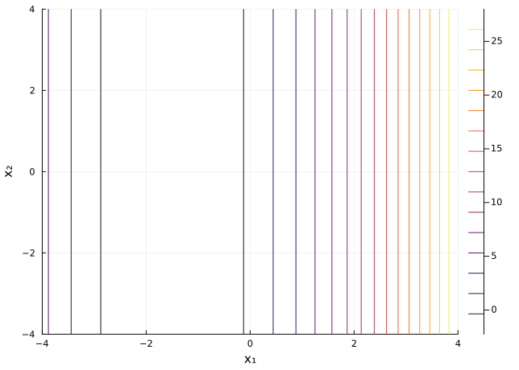

(b) Contour plot

Figure 4: Quadratic function with a singular point

```julia
f(x) = 1/2*dot(x,Q*x)+dot(x,r)

x1_data = x2_data = -4:0.1:4;
f_data = [f([x1,x2]) for x2=x2_data, x1=x1_data];

using Plots
# Create a 2x1 layout for the plots
p1 = surface(x1_data, x2_data, f_data, xlabel="x₁", ylabel="x₂", zlabel="f(x)", colorbar=false)
display(p1) # This is only need here for Quarto to render the two subfigures side by side.

# Create the second plot (contour)
p2 = contour(x1_data, x2_data, f_data, xlabel="x₁", ylabel="x₂")
display(p2)
```

**Example 6 (Singular point of a non-quadratic function)** Consider the function $f(\bm x) = x_1^2 + x_2^4$. Its gradient is $\nabla f(\bm x) = \begin{bmatrix}2x_1\\ 4x_2^3\end{bmatrix}$ and it vanishes at $\bm x^\star = \begin{bmatrix}0\\ 0\end{bmatrix}$. The Hessian is $\nabla^2 f(\bm x) = \begin{bmatrix}2 & 0\\ 0 & 12x_2^2\end{bmatrix}$, which when evaluated at the stationary point is $\nabla^2 f(\bm x)\bigg|_{\bm x=\mathbf 0} = \begin{bmatrix}2 & 0\\ 0 & 0\end{bmatrix}$, which is positive semidefinite. We cannot conclude if the function attains a minimum at $\bm x^\star$.

We need to examine higher-order terms in the Taylor series expansion. The third derivatives are
$$\frac{\partial^3 f}{\partial x_1^3} = 0, \quad \frac{\partial^3 f}{\partial x_1^2\partial x_2} = 0, \quad \frac{\partial^3 f}{\partial x_1\partial x_2^2} = 0, \quad \frac{\partial^3 f}{\partial x_2^3} = 24x_2,$$
and when evaluated at zero, they all vanish.

All but one fourth derivatives also vanish. The one that does not is
$$\frac{\partial^4 f}{\partial x_2^4} = 24,$$
which is positive, and since the associated derivative is of the even order, the power si also even, hence the function attains a minimum at $\bm x^\star = \begin{bmatrix}0\\ 0\end{bmatrix}$.

This can also be visually confirmed by the surface and contour plots of the function.

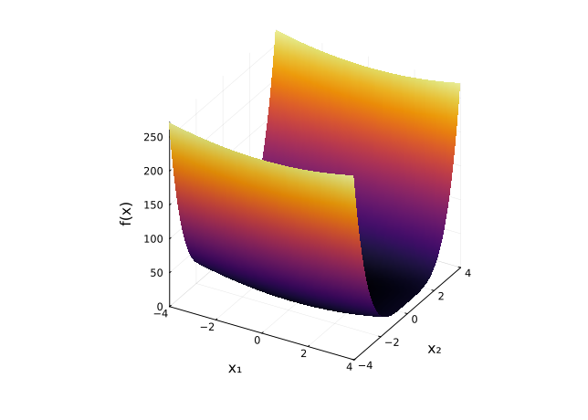

(a) Surface plot

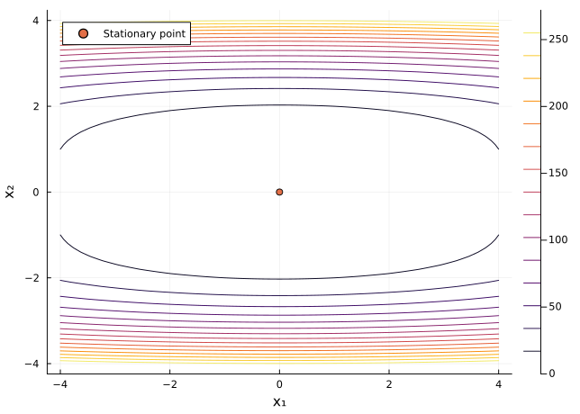

(b) Contour plot

Figure 5: Singular point of a non-quadratic function that turns out to be a minimum

```julia
f(x) = x[1]^2 + x[2]^4

x1_data = x2_data = -4:0.1:4;
f_data = [f([x1,x2]) for x2=x2_data, x1=x1_data];

using Plots
# Create a 2x1 layout for the plots
p1 = surface(x1_data, x2_data, f_data, xlabel="x₁", ylabel="x₂", zlabel="f(x)", colorbar=false)
display(p1)

# Create the second plot (contour)
p2 = contour(x1_data, x2_data, f_data, xlabel="x₁", ylabel="x₂")
# Add the stationary point to the contour plot
scatter!([0.0], [0.0], marker=:circle, label="Stationary point")
display(p2)
```

# Constrained optimization

## Equality constraints

### Lagrange multipliers and Lagrangian function

We consider the following optimization problem with equality constraints
$$\begin{aligned}
\operatorname*{minimize}_{\bm x\in\mathbb{R}^n} &\quad f(\bm x)\\
\text{subject to} &\quad \mathbf h(\bm x) = \mathbf 0,
\end{aligned}$$
where $\mathbf h(\bm x) \in \mathbb R^m$ defines a set of $m$ equations
$$\begin{aligned}
h_1(\bm x) &= 0\\
h_2(\bm x) &= 0\\
\vdots\\
h_m(\bm x) &= 0.
\end{aligned}$$

Augmenting the original cost function $f$ with the constraint functions $h_i$ scaled by Lagrange variables $\lambda_i$ gives the Lagrangian function
$$\mathcal{L}(\bm x,\boldsymbol\lambda) \coloneqq f(\bm x) + \sum_{i=1}^m \lambda_i h_i(\bm x) = f(\bm x) + \boldsymbol \lambda^\top \mathbf h(\bm x).$$

### First-order necessary condition of optimality

[video not shown]

The first-order necessary condition of optimality is
$$\nabla \mathcal{L}(\bm x,\boldsymbol\lambda) = \mathbf 0,$$
which amounts to two (generally vector) equations
$$\boxed{
\begin{aligned}
\nabla f(\bm x) + \sum_{i=1}^m \lambda_i \nabla h_i(\bm x) &= \mathbf 0\\
\mathbf{h}(\bm x) &= \mathbf 0.
\end{aligned}}$$

Defining a matrix $\nabla \mathbf h(\bm x) \in \mathbb R^{n\times m}$ as horizontally stacked gradients of the constraint functions
$$\nabla \mathbf h(\bm x) \coloneqq \begin{bmatrix}
\nabla h_1(\bm x) && \nabla h_2(\bm x) && \ldots && \nabla h_m(\bm x)
\end{bmatrix},$$
in fact, a transpose of the Jacobian matrix, the necessary condition can be rewritten in a vector form as
$$\boxed
{\begin{aligned}
\nabla f(\bm x) + \nabla \mathbf h(\bm x)\boldsymbol \lambda &= \mathbf 0\\
\mathbf{h}(\bm x) &= \mathbf 0.
\end{aligned}}$$

Beware of the nonregularity issue! The $(\nabla \mathbf h(\bm x))^\mathrm T$ is regular at a given $\bm x$ (the $\bm x$ is a regular point) if it has a full column rank. Rank-deficiency reveals a defect in formulation.

**Example 7 (Equality-constrained quadratic program)**
$$\begin{aligned}
\operatorname*{minimize}_{\bm x \in \mathbb{R}^n} &\quad \frac{1}{2}\bm{x}^\top\mathbf{Q}\bm{x} + \mathbf{r}^\top\bm{x}\\
\text{subject to} &\quad \mathbf A \bm x = \mathbf b.
\end{aligned}$$

The first-order necessary condition of optimality is

$$\begin{bmatrix}
\mathbf Q & \mathbf A^\top\\\mathbf A & \mathbf 0
\end{bmatrix}
\begin{bmatrix}
\bm x \\ \boldsymbol \lambda
\end{bmatrix}
=
\begin{bmatrix}
-\mathbf r\\\mathbf b
\end{bmatrix}.$$

### Second-order sufficient conditions

[video not shown]

Using the unconstrained Hessian $\nabla^2_{\mathbf{x}\bm{x}} \mathcal{L}(\bm x,\boldsymbol \lambda)$ is too conservative. Instead, use projected Hessian

$$\mathbf{Z}^\mathrm{T}\;\nabla^2_{\bm{x}\bm{x}} \mathcal{L}(\bm x,\boldsymbol \lambda)\;\mathbf Z > 0,$$
where $\mathbf Z$ is an (orthonormal) basis of the nullspace of the Jacobian $(\nabla \mathbf h(\bm x))^\top$.

## Inequality constraints

[video not shown]

$$\begin{aligned}
\operatorname*{minimize}_{\bm x\in\mathbb{R}^n} &\quad f(\bm x)\\
\text{subject to} &\quad \mathbf g(\bm x) \leq \mathbf 0,
\end{aligned}$$
where $\mathbf g(\bm x) \in \mathbb R^p$ defines a set of $p$ inequalities.

### First-order necessary condition of optimality

Karush-Kuhn-Tucker (KKT) conditions of optimality are then composed of these four (sets of) conditions
$$\boxed{
\begin{aligned}
\nabla f(\bm x) + \sum_{i=1}^p \mu_i \nabla g_i(\bm x) &= \mathbf 0,\\
\mathbf{g}(\bm{x}) &\leq \mathbf 0,\\
\mu_i &\geq 0,\quad i = 1,2,\ldots, m,\\
\mu_i g_i(\bm x) &= 0,\quad i = 1,2,\ldots, m.
\end{aligned}
}$$

## Equality and inequality constraints

$$\begin{aligned}
\operatorname*{minimize}_{\bm x\in\mathbb{R}^n} &\quad f(\bm x)\\
\text{subject to} &\quad \mathbf h(\bm x) = \mathbf 0,\\
&\quad \mathbf g(\bm x) \leq \mathbf 0.
\end{aligned}$$

### First-order necessary condition of optimality

The KKT conditions

$$\boxed{
\begin{aligned}
\nabla f(\bm x) + \sum_{i=1}^m \lambda_i \nabla h_i(\bm x) + \sum_{i=1}^p \mu_i \nabla g_i(\bm x) &= \mathbf 0\\
\mathbf{h}(\mathbf{x}) &= \mathbf 0\\
\mathbf{g}(\mathbf{x}) &\leq \mathbf 0\\
\mu_i &\geq 0,\quad i = 1,\ldots, m,\\
\mu_i g_i(\bm x) &= 0,\quad i = 1,\ldots, m.
\end{aligned}
}$$

## Duality

Duality theory offers another view of the original optimization problem by bringing in another but related one.

Corresponding to the general optimization problem
$$\begin{aligned}
\operatorname*{minimize}\;&f(\bm x)\\
\text{subject to}\; & \mathbf g(\bm x)\leq \mathbf 0\\
& \mathbf h(\bm x) = \mathbf 0,
\end{aligned}$$

we form the *Lagrangian* function
$$\mathcal L(\bm x,\bm \lambda,\bm \mu) = f(\bm x) + \bm \lambda^\top \mathbf h(\bm x) + \bm \mu^\top \mathbf g(\bm x)$$

For any (fixed) values of $(\bm \lambda,\bm \mu)$ such that $\bm \mu\geq 0$, we define the *Lagrange dual function* through the following unconstrained optimization problem
$$q(\bm\lambda,\bm\mu) = \inf_{\bm x}\mathcal L(\bm x,\bm \lambda,\bm \mu).$$

Obviously, it is alway possible to pick a feasible solution $\bm x$, in which case the value of the Lagrangian and the original function coincide, and so the result of this minimization is no worse (larger) than the minimum for the original optimization problem. It can thus serve as a lower bound
$$q(\bm \lambda,\bm \mu) \leq f(\bm x^\star).$$

This result is called *weak duality*. A natural idea is to find the values of $\bm \lambda$ and $\bm \mu$ such that this lower bound is tightest, that is,
$$\begin{aligned}
\operatorname*{maximize}_{\bm\lambda, \bm\mu}\; & q(\bm\lambda,\bm\mu)\\
\text{subject to}\;& \bm\mu \geq \mathbf 0.
\end{aligned}$$

Under some circumstances the result can be tight, which leads to *strong duality*, which means that the minimum of the original (primal) problem and the maximum of the dual problem coincide.
$$q(\bm \lambda^\star,\bm \mu^\star) = f(\bm x^\star).$$

This related dual optimization problem can have some advantages for development of both theory and algorithms.

Back to top